# Latihan 2 — Autoregressive Distributed Lag (ARDL)

STA1341 Metode Peramalan Deret Waktu — Sales vs Advertising

Rizky Arif Wicaksono (M0401241054)

04 September 2026

# 1 Soal

> Lakukan pemodelan **ARDL** yang sesuai menggunakan data Sales dan Advertising tahun 1975–2014, dan temukan model terbaik!

Alur pengerjaan mengikuti tahapan praktikum: **impor data → cek stasioneritas → bagi train/test → bangun ARDL dasar → cari orde optimum → forecast pada data test → uji diagnostik → pilih model terbaik**.

# 2 Impor Data

```r
Year        <- 1975:2014
Sales       <- c(11.7,12.0,12.3,12.8,13.1,13.6,13.9,14.4,14.7,15.3,
                  15.5,15.8,16.1,16.6,16.9,16.7,16.9,17.4,17.6,17.9,
                  18.0,17.9,18.0,18.2,18.2,18.3,18.6,19.2,19.3,19.5,
                  19.2,19.3,19.5,20.0,20.0,19.9,19.8,19.9,20.2,21.0)
Advertising <- c(9.4,9.6,10.0,10.4,10.8,10.9,11.7,12.2,12.5,12.9,
                  13.0,13.2,13.8,14.2,14.6,14.4,15.0,15.4,15.7,15.9,
                  15.9,16.0,16.3,16.2,16.8,17.3,17.6,18.1,18.3,18.5,
                  18.7,18.9,19.2,20.0,20.0,20.3,20.4,21.0,21.5,22.1)

data2 <- data.frame(Year, Sales, Advertising)
str(data2)
```

```
## 'data.frame':    40 obs. of  3 variables:
##  $ Year       : int  1975 1976 1977 1978 1979 1980 1981 1982 1983 1984 ...
##  $ Sales      : num  11.7 12 12.3 12.8 13.1 13.6 13.9 14.4 14.7 15.3 ...
##  $ Advertising: num  9.4 9.6 10 10.4 10.8 10.9 11.7 12.2 12.5 12.9 ...
```

```r
data2
```

| Year | Sales | Advertising |
| --- | --- | --- |
| 1975 | 11.7 | 9.4 |
| 1976 | 12.0 | 9.6 |
| 1977 | 12.3 | 10.0 |
| 1978 | 12.8 | 10.4 |
| 1979 | 13.1 | 10.8 |
| 1980 | 13.6 | 10.9 |
| 1981 | 13.9 | 11.7 |
| 1982 | 14.4 | 12.2 |
| 1983 | 14.7 | 12.5 |
| 1984 | 15.3 | 12.9 |

[output cut: 30 more lines]

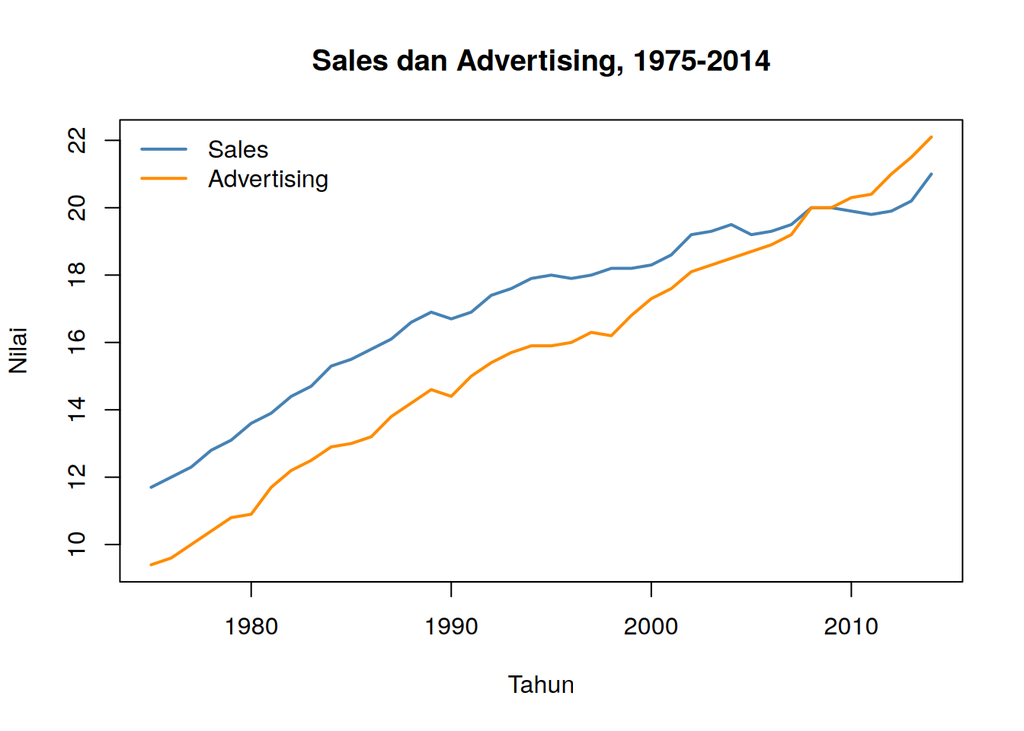

```r
plot(data2$Year, data2$Sales, type = "l", col = "steelblue", lwd = 2,
     xlab = "Tahun", ylab = "Nilai", main = "Sales dan Advertising, 1975-2014",
     ylim = range(c(data2$Sales, data2$Advertising)))
lines(data2$Year, data2$Advertising, col = "darkorange", lwd = 2)
legend("topleft", legend = c("Sales", "Advertising"),
       col = c("steelblue", "darkorange"), lwd = 2, bty = "n")
```

Kedua peubah menunjukkan tren naik yang kuat dan bergerak berdekatan.

# 3 Cek Stasioneritas (ADF)

```r
adf.test(data2$Sales)
```

```
##
##  Augmented Dickey-Fuller Test
##
## data:  data2$Sales
## Dickey-Fuller = -2.2728, Lag order = 3, p-value = 0.4664
## alternative hypothesis: stationary
```

```r
adf.test(data2$Advertising)
```

```
##
##  Augmented Dickey-Fuller Test
##
## data:  data2$Advertising
## Dickey-Fuller = -2.2643, Lag order = 3, p-value = 0.4697
## alternative hypothesis: stationary
```

```r
adf.test(diff(data2$Sales))
```

```
##
##  Augmented Dickey-Fuller Test
##
## data:  diff(data2$Sales)
## Dickey-Fuller = -3.1671, Lag order = 3, p-value = 0.1163
## alternative hypothesis: stationary
```

```r
adf.test(diff(data2$Advertising))
```

```
##
##  Augmented Dickey-Fuller Test
##
## data:  diff(data2$Advertising)
## Dickey-Fuller = -3.3774, Lag order = 3, p-value = 0.07515
## alternative hypothesis: stationary
```

# 4 Pembagian Data (Train/Test)

Data dibagi 75:25 — 30 tahun pertama (1975–2004) untuk *training*, 10 tahun terakhir (2005–2014) untuk *testing*.

```r
train <- data2[1:30, ]
test  <- data2[31:40, ]
```

# 5 Model ARDL

## 5.1 Model dasar (p = 1, q = 1)

```r
model.ardl <- ardlDlm(formula = Sales ~ Advertising, data = train, p = 1, q = 1)
summary(model.ardl)
```

```
##
## Time series regression with "ts" data:
## Start = 2, End = 30
##
## Call:
## dynlm(formula = as.formula(model.text), data = data)
##
## Residuals:
##       Min        1Q    Median        3Q       Max
## -0.229277 -0.127437  0.009143  0.109228  0.259132
##
## Coefficients:
##               Estimate Std. Error t value Pr(>|t|)
## (Intercept)    1.55786    0.44353   3.512  0.00171 **
## Advertising.t  0.29110    0.13707   2.124  0.04376 *
## Advertising.1 -0.09584    0.16067  -0.596  0.55621
## Sales.1        0.74360    0.09964   7.463 8.14e-08 ***
## ---
## Signif. codes:  0 '***' 0.001 '**' 0.01 '*' 0.05 '.' 0.1 ' ' 1
##
## Residual standard error: 0.1576 on 25 degrees of freedom
## Multiple R-squared:  0.9955, Adjusted R-squared:  0.9949
## F-statistic:  1830 on 3 and 25 DF,  p-value: < 2.2e-16
```

```r
fore.ardl <- forecast(model = model.ardl, x = test$Advertising, h = 10)
mape.ardl <- MAPE(fore.ardl$forecasts, test$Sales)
mape.ardl
```

```
## [1] 0.0484832
```

## 5.2 Pencarian Orde Optimum (p, q)

Pencarian orde ARDL menggunakan `ardlBoundOrders()` — kriteria AIC — pada seluruh data, dibatasi `max.p = max.q = 5` agar derajat bebas tetap memadai untuk n = 40.

```r
opt.ardl <- ardlBoundOrders(data = data.frame(data2), ic = "AIC",
                             formula = Sales ~ Advertising, max.p = 5, max.q = 5)
opt.ardl
```

[output not shown]

```r
p.opt <- as.numeric(opt.ardl$p["Advertising"])
q.opt <- opt.ardl$q
cat("Orde optimum (AIC minimum): p =", p.opt, ", q =", q.opt, "\n")
```

```
## Orde optimum (AIC minimum): p = 5 , q = 1
```

**Catatan penting soal notasi:** pada fungsi `ardlDlm()` dari package `dLagM`, argumen **`p` adalah orde lag untuk peubah independen X** (Advertising), sedangkan **`q` adalah orde autoregresif untuk peubah dependen Y** (Sales) — ini **kebalikan** dari notasi $ARDL(p,q)$ pada rumus umum di slide perkuliahan ($Y_t = \alpha + \phi_1 Y_{t-1} + \dots + \phi_p Y_{t-p} + \beta_0 X_t + \dots + \beta_q X_{t-q} + \varepsilon_t$, di mana $p$ = orde AR untuk Y dan $q$ = orde DL untuk X). Supaya tidak ambigu, hasil di atas berarti: **Advertising dimasukkan hingga lag ke-5**, dan **Sales dimasukkan hingga lag ke-1** (AR).

```r
model.ardl2 <- ardlDlm(formula = Sales ~ Advertising, data = train, p = p.opt, q = q.opt)
summary(model.ardl2)
```

```
##
## Time series regression with "ts" data:
## Start = 6, End = 30
##
## Call:
## dynlm(formula = as.formula(model.text), data = data)
##
## Residuals:
##      Min       1Q   Median       3Q      Max
## -0.28236 -0.09842  0.02340  0.07893  0.21883
##
## Coefficients:
##               Estimate Std. Error t value Pr(>|t|)
## (Intercept)    2.06360    0.95003   2.172 0.044281 *
## Advertising.t  0.26282    0.15197   1.729 0.101844
## Advertising.1  0.11406    0.19053   0.599 0.557324
## Advertising.2 -0.14136    0.19095  -0.740 0.469222
## Advertising.3  0.05926    0.18843   0.314 0.756992
## Advertising.4 -0.18301    0.18916  -0.967 0.346868
## Advertising.5  0.10976    0.14565   0.754 0.461425
## Sales.1        0.68919    0.15661   4.401 0.000391 ***
## ---
## Signif. codes:  0 '***' 0.001 '**' 0.01 '*' 0.05 '.' 0.1 ' ' 1
##
## Residual standard error: 0.1585 on 17 degrees of freedom
## Multiple R-squared:  0.9938, Adjusted R-squared:  0.9912
## F-statistic: 387.2 on 7 and 17 DF,  p-value: < 2.2e-16
```

```r
fore.ardl2 <- forecast(model = model.ardl2, x = test$Advertising, h = 10)
mape.ardl2 <- MAPE(fore.ardl2$forecasts, test$Sales)
mape.ardl2
```

```
## [1] 0.04084408
```

Perhatikan bahwa pada model ARDL(5,1) sebagian besar koefisien lag *Advertising* individual tidak signifikan — ini gejala **multikolinearitas** yang wajar terjadi karena banyak lag dari peubah yang sama, saling berkorelasi tinggi (data bertren). Meski demikian, model tetap valid untuk peramalan (uji-F keseluruhan tetap signifikan).

## 5.3 Perbandingan Sebagai Pembanding: DLM & Koyck

Sebagai pembanding tambahan (bukan diminta soal, tapi untuk melengkapi kerangka *distributed lag* secara umum):

```r
model.koyck <- koyckDlm(x = train$Advertising, y = train$Sales)
fore.koyck  <- forecast(model = model.koyck, x = test$Advertising, h = 10)
mape.koyck  <- MAPE(fore.koyck$forecasts, test$Sales)

model.dlm   <- dlm(formula = Sales ~ Advertising, data = train, q = 2)
fore.dlm    <- forecast(model = model.dlm, x = test$Advertising, h = 10)
mape.dlm    <- MAPE(fore.dlm$forecasts, test$Sales)

cat("MAPE Koyck   :", mape.koyck, "\n")
```

```
## MAPE Koyck   : 0.04712769
```

```r
cat("MAPE DLM(q=2):", mape.dlm, "\n")
```

```
## MAPE DLM(q=2): 0.06098542
```

# 6 Uji Diagnostik (Model ARDL Terpilih)

`dLagM::ardlDlm()` pada dasarnya membungkus `dynlm`, sehingga objek model dapat langsung diuji dengan `lmtest`.

```r
dwtest(model.ardl2$model)
```

```
##
##  Durbin-Watson test
##
## data:  model.ardl2$model
## DW = 1.9282, p-value = 0.2732
## alternative hypothesis: true autocorrelation is greater than 0
```

```r
bptest(model.ardl2$model)
```

```
##
##  studentized Breusch-Pagan test
##
## data:  model.ardl2$model
## BP = 6.9589, df = 7, p-value = 0.4332
```

```r
shapiro.test(residuals(model.ardl2$model))
```

```
##
##  Shapiro-Wilk normality test
##
## data:  residuals(model.ardl2$model)
## W = 0.96917, p-value = 0.6241
```

Ketiga uji asumsi klasik (non-autokorelasi, homoskedastisitas, normalitas galat) **terpenuhi** pada taraf nyata 5%, sehingga model ARDL di atas layak digunakan.

# 7 Perbandingan Model & Pemilihan Model Terbaik

```r
akurasi <- data.frame(
  Model = c("ARDL (1,1)", paste0("ARDL (", p.opt, ",", q.opt, ", optimum)"),
            "Koyck (pembanding)", "DLM q=2 (pembanding)"),
  AIC = c(AIC(model.ardl), AIC(model.ardl2), AIC(model.koyck), AIC(model.dlm)),
  BIC = c(BIC(model.ardl), BIC(model.ardl2), BIC(model.koyck), BIC(model.dlm)),
  MAPE_test = round(c(mape.ardl, mape.ardl2, mape.koyck, mape.dlm), 5)
)
```

[output not shown]

```r
akurasi[order(akurasi$MAPE_test), ]
```

|  | Model | AIC | BIC | MAPE_test |
| --- | --- | --- | --- | --- |
| 2 | ARDL (5,1, optimum) | -12.79539 | -1.825505 | 0.04084 |
| 3 | Koyck (pembanding) | -20.60961 | -15.140428 | 0.04713 |
| 1 | ARDL (1,1) | -19.18177 | -12.345286 | 0.04848 |
| 4 | DLM q=2 (pembanding) | 10.65158 | 17.312600 | 0.06099 |

## 7.1 Plot Perbandingan Forecast vs Aktual

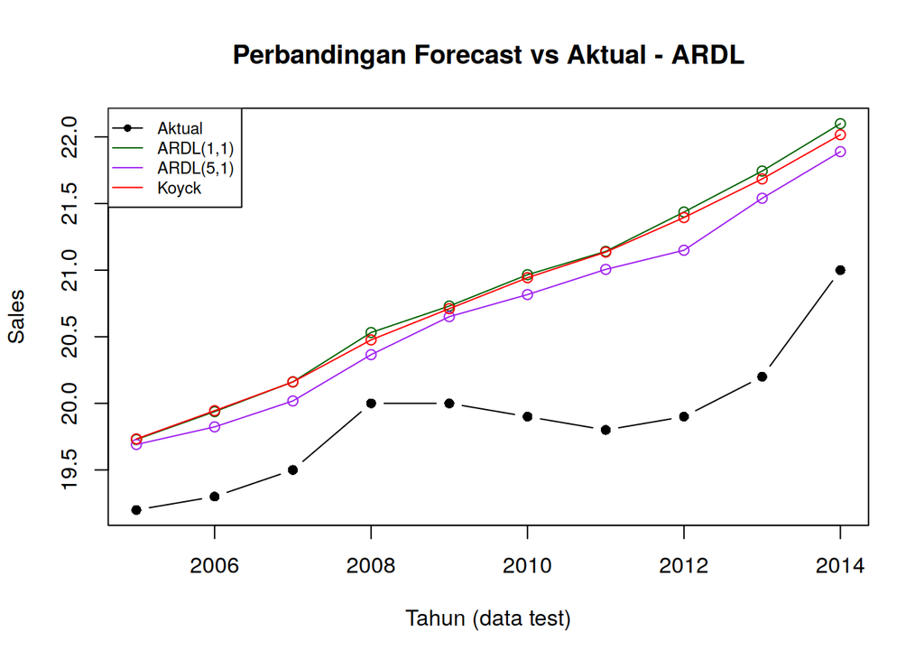

```r
plot(test$Year, test$Sales, type = "b", col = "black", pch = 16,
     ylim = range(c(test$Sales, fore.ardl$forecasts, fore.ardl2$forecasts,
                     fore.koyck$forecasts)),
     xlab = "Tahun (data test)", ylab = "Sales",
     main = "Perbandingan Forecast vs Aktual - ARDL")
points(test$Year, fore.ardl$forecasts, col = "darkgreen"); lines(test$Year, fore.ardl$forecasts, col = "darkgreen")
points(test$Year, fore.ardl2$forecasts, col = "purple"); lines(test$Year, fore.ardl2$forecasts, col = "purple")
points(test$Year, fore.koyck$forecasts, col = "red"); lines(test$Year, fore.koyck$forecasts, col = "red")
legend("topleft", c("Aktual", "ARDL(1,1)", paste0("ARDL(",p.opt,",",q.opt,")"), "Koyck"),
       lty = 1, pch = c(16, NA, NA, NA),
       col = c("black", "darkgreen", "purple", "red"), cex = 0.75)
```

Berdasarkan **MAPE data test**, model **ARDL(5,1)** memberikan akurasi peramalan luar-sampel terbaik (MAPE = 4.08%), sehingga dipilih sebagai **model ARDL terbaik** untuk data Sales–Advertising ini.

# 8 Model Terbaik & Interpretasi

```r
coefs <- coef(model.ardl2$model)
coefs
```

```
##   (Intercept) Advertising.t Advertising.1 Advertising.2 Advertising.3
##    2.06359579    0.26282287    0.11405631   -0.14135925    0.05925641
## Advertising.4 Advertising.5       Sales.1
##   -0.18301056    0.10975630    0.68919282
```

```r
# nama koefisien mengikuti pola "<nama_Y>.<lag>" dan "<nama_X>.t"/"<nama_X>.<lag>"
phi_names  <- names(coefs)[grepl("^Sales", names(coefs))]
beta_names <- names(coefs)[grepl("^Advertising", names(coefs))]

phi   <- sum(coefs[phi_names])          # jumlah seluruh koefisien lag Sales (AR)
betas <- coefs[beta_names]              # seluruh koefisien Advertising (lag 0..p)
LR_multiplier <- sum(betas) / (1 - phi)

cat("Koefisien lag Sales (AR):\n"); print(coefs[phi_names])
```

```
## Koefisien lag Sales (AR):
```

```
##   Sales.1
## 0.6891928
```

```r
cat("\nKoefisien Advertising (lag 0..p):\n"); print(betas)
```

```
##
## Koefisien Advertising (lag 0..p):
```

```
## Advertising.t Advertising.1 Advertising.2 Advertising.3 Advertising.4
##    0.26282287    0.11405631   -0.14135925    0.05925641   -0.18301056
## Advertising.5
##    0.10975630
```

```r
cat("\nJumlah phi (AR):", phi, "\n")
```

```
##
## Jumlah phi (AR): 0.6891928
```

```r
cat("Long-run multiplier:", LR_multiplier, "\n")
```

```
## Long-run multiplier: 0.7127315
```

**Model dugaan ARDL (Advertising lag 0–5, Sales lag AR 1–1):**

$$\widehat{Sales}_t = 2.0636 + \sum_{i=1}^{1}\phi_i\,Sales_{t-i} +
\sum_{j=0}^{5}\beta_j\,Advertising_{t-j}$$

(koefisien lengkap lihat output `summary(model.ardl2)` di atas; `p` di sini mengikuti konvensi `dLagM` = orde lag Advertising, `q` = orde AR Sales — lihat catatan notasi pada bagian sebelumnya)

**Interpretasi:**

- **Koefisien $Sales_{t-1}$** (0.6892, signifikan) menunjukkan **persistensi/kelembaman yang sangat kuat** — sebagian besar level Sales tahun ini “diwariskan” dari tahun sebelumnya, konsisten dengan pola tren naik pada data.
- Koefisien lag-lag *Advertising* secara individual banyak yang tidak signifikan akibat multikolinearitas antar-lag, namun **secara bersama-sama** (uji F) tetap signifikan mempengaruhi Sales.
- **Dampak jangka panjang (*long-run multiplier*)**:
  $$\text{LR multiplier} = \frac{\sum \beta_j}{1-\sum\phi_i} = 0.7127$$
  Artinya, jika belanja iklan dinaikkan secara permanen sebesar 1 unit, Sales akan meningkat total sebesar 0.7127 unit dalam jangka panjang setelah seluruh proses penyesuaian selesai.
- Model ini memberikan **MAPE data test terkecil** di antara seluruh model ARDL yang dicoba, menandakan performa peramalan luar-sampel yang paling baik untuk data ini.